# Lab 4: A Clinical Prediction Pipeline on METABRIC TNBC

Bright Joses

2026-11-22

> **AI use statement.** This submission was produced with substantial help from Claude, an AI assistant made by Anthropic. Claude wrote the R code, ran the analyses and drafted the written answers and tables in this file. It was not used only to explain a concept or an error message. All results come from running the code in this file on the supplied TNBC data.

# Scope and prediction task

The file used is the METABRIC triple-negative (TNBC) subset: `tnbc_clinical.csv` (30 clinical columns) joined to `tnbc_mutation.csv` (18 gene mutation flags) by patient ID. Only this subset was available to me, so every step below (classification, missingness, imputation, leakage audit, pipeline) is run on it.

**Prediction task.** Predict whether a patient *died of disease* (`VITAL_STATUS = "Died of Disease"`) from information available at one moment: **the tumour-board meeting after surgery and tumour profiling, before adjuvant chemotherapy, radiotherapy or hormone therapy is decided.** Everything in the leakage audit is judged against that moment.

```r
cl <- read.csv("tnbc_clinical.csv", na.strings = c("NA", ""), check.names = FALSE,
               stringsAsFactors = FALSE)
mu <- read.csv("tnbc_mutation.csv", check.names = FALSE)
names(cl)[1] <- "PATIENT_ID"; names(mu)[1] <- "PATIENT_ID"
stopifnot(all(cl$PATIENT_ID == mu$PATIENT_ID))
genes <- setdiff(names(mu), "PATIENT_ID")
dat <- merge(cl, mu, by = "PATIENT_ID", sort = FALSE)
dat$y <- factor(ifelse(dat$VITAL_STATUS == "Died of Disease", "Died", "Living"),
                levels = c("Living", "Died"))
c(patients = nrow(dat), clinical_cols = ncol(cl), gene_cols = length(genes))
```

```
##      patients clinical_cols     gene_cols
##           190            30            18
```

```r
table(dat$y)
```

```
##
## Living   Died
##    107     83
```

# 1. Classify every variable

```r
vc <- function(v, role, type, note = "") data.frame(variable = v, role = role, type = type, note = note)
classification <- rbind(
  vc("PATIENT_ID", "identifier", "nominal", "Row key, not a variable"),
  vc("AGE_AT_DIAGNOSIS", "clinical", "numeric", "Years"),
  vc("BREAST_SURGERY", "treatment", "binary", "Conserving vs mastectomy; done before the prediction moment"),
  vc("CANCER_TYPE", "clinical", "constant", "'Breast Cancer' for every patient"),
  vc("CANCER_TYPE_DETAILED", "clinical", "nominal", "Histology label, vocabulary 1"),
  vc("CELLULARITY", "clinical", "ordinal", "low < moderate < high"),
  vc("CHEMOTHERAPY", "treatment", "binary", "Adjuvant, decided after the prediction moment"),
  vc("RADIO_THERAPY", "treatment", "binary", "Adjuvant; 'YES' for every patient"),
  vc("HORMONE_THERAPY", "treatment", "binary", "Adjuvant, decided after the prediction moment"),
  vc("CLAUDIN_SUBTYPE", "genomic", "nominal", "Expression-based subtype"),
  vc("COHORT", "clinical", "nominal", "Study cohort (1-5): administrative"),
  vc("ER_IHC", "clinical", "binary", "Immunohistochemistry ER result"),
  vc("ER_STATUS", "clinical", "constant", "'-' for every patient (TNBC definition)"),
  vc("PR_STATUS", "clinical", "constant", "'-' for every patient (TNBC definition)"),
  vc("HER2_STATUS", "clinical", "constant", "'-' for every patient (TNBC definition)"),
  vc("GRADE", "clinical", "ordinal", "Tumour grade 1 < 2 < 3"),
  vc("HER2_SNP6", "genomic", "nominal", "HER2 copy-number call (GAIN/LOSS/NEUT)"),
  vc("MUTATION_COUNT", "genomic", "numeric (count)", "Number of mutations"),
  vc("HISTOLOGICAL_SUBTYPE", "clinical", "nominal", "Histology label, vocabulary 2"),
  vc("INFERRED_MENOPAUSAL_STATE", "clinical", "binary", "pre / post"),
  vc("INTCLUST", "genomic", "nominal", "Integrative cluster (copy number + expression)"),
  vc("LATERALITY", "clinical", "binary", "Left / right"),
  vc("NPI", "clinical", "numeric", "Nottingham Prognostic Index"),
  vc("ONCOTREE_CODE", "clinical", "nominal", "Histology label, vocabulary 3"),
  vc("OS_MONTHS", "outcome", "numeric", "Overall survival time"),
  vc("SAMPLE_TYPE", "clinical", "constant", "'Primary' for every patient"),
  vc("THREEGENE", "genomic", "nominal", "Three-gene classifier from expression"),
  vc("TUMOR_SIZE", "clinical", "numeric", "mm"),
  vc("TUMOR_STAGE", "clinical", "ordinal", "0 < 1 < 2 < 3"),
  vc("VITAL_STATUS", "outcome", "binary", "The label: Died of Disease / Living"),
  do.call(rbind, lapply(genes, function(g) vc(g, "genomic", "binary", "Gene mutated (1) or not (0)")))
)
rownames(classification) <- NULL
stopifnot(setequal(classification$variable, c(names(cl), genes)))
table(classification$role)
```

```
##
##   clinical    genomic identifier    outcome  treatment
##         18         23          1          2          4
```

```r
knitr::kable(classification[classification$role != "genomic" | !classification$variable %in% genes, ])
```

| variable | role | type | note |
| --- | --- | --- | --- |
| PATIENT_ID | identifier | nominal | Row key, not a variable |
| AGE_AT_DIAGNOSIS | clinical | numeric | Years |
| BREAST_SURGERY | treatment | binary | Conserving vs mastectomy; done before the prediction moment |
| CANCER_TYPE | clinical | constant | ‘Breast Cancer’ for every patient |
| CANCER_TYPE_DETAILED | clinical | nominal | Histology label, vocabulary 1 |
| CELLULARITY | clinical | ordinal | low < moderate < high |
| CHEMOTHERAPY | treatment | binary | Adjuvant, decided after the prediction moment |
| RADIO_THERAPY | treatment | binary | Adjuvant; ‘YES’ for every patient |
| HORMONE_THERAPY | treatment | binary | Adjuvant, decided after the prediction moment |
| CLAUDIN_SUBTYPE | genomic | nominal | Expression-based subtype |
| COHORT | clinical | nominal | Study cohort (1-5): administrative |
| ER_IHC | clinical | binary | Immunohistochemistry ER result |
| ER_STATUS | clinical | constant | ‘-’ for every patient (TNBC definition) |
| PR_STATUS | clinical | constant | ‘-’ for every patient (TNBC definition) |
| HER2_STATUS | clinical | constant | ‘-’ for every patient (TNBC definition) |
| GRADE | clinical | ordinal | Tumour grade 1 < 2 < 3 |
| HER2_SNP6 | genomic | nominal | HER2 copy-number call (GAIN/LOSS/NEUT) |
| MUTATION_COUNT | genomic | numeric (count) | Number of mutations |
| HISTOLOGICAL_SUBTYPE | clinical | nominal | Histology label, vocabulary 2 |
| INFERRED_MENOPAUSAL_STATE | clinical | binary | pre / post |
| INTCLUST | genomic | nominal | Integrative cluster (copy number + expression) |
| LATERALITY | clinical | binary | Left / right |
| NPI | clinical | numeric | Nottingham Prognostic Index |
| ONCOTREE_CODE | clinical | nominal | Histology label, vocabulary 3 |
| OS_MONTHS | outcome | numeric | Overall survival time |
| SAMPLE_TYPE | clinical | constant | ‘Primary’ for every patient |
| THREEGENE | genomic | nominal | Three-gene classifier from expression |
| TUMOR_SIZE | clinical | numeric | mm |
| TUMOR_STAGE | clinical | ordinal | 0 < 1 < 2 < 3 |
| VITAL_STATUS | outcome | binary | The label: Died of Disease / Living |

The 18 mutation columns (AKT1, MAP3K1, MEN1, NCOR2, PIK3CA, SHANK2, MAP2K4, AGMO, TAF1, GATA3, BIRC6, DNAH11, NF1, TP53, SYNE1, CTNNA1, FOXO3, LDLRAP1) are all **genomic**, binary variables.

# 2. Missingness: by variable, and its pattern

## By variable

```r
miss_tab <- data.frame(variable = names(cl),
                       n_missing = sapply(cl, function(x) sum(is.na(x))))
miss_tab$pct_missing <- round(100 * miss_tab$n_missing / nrow(cl), 1)
miss_tab <- miss_tab[miss_tab$n_missing > 0, ]
miss_tab[order(-miss_tab$n_missing), ]
```

```
##                variable n_missing pct_missing
## TUMOR_STAGE TUMOR_STAGE        46        24.2
## THREEGENE     THREEGENE        35        18.4
## LATERALITY   LATERALITY         9         4.7
## CELLULARITY CELLULARITY         6         3.2
## ER_IHC           ER_IHC         2         1.1
## GRADE             GRADE         2         1.1
## TUMOR_SIZE   TUMOR_SIZE         1         0.5
```

Seven variables have gaps and the remaining 22 (apart from the ID) are complete. The gene mutation file has no missing values.

## Pattern

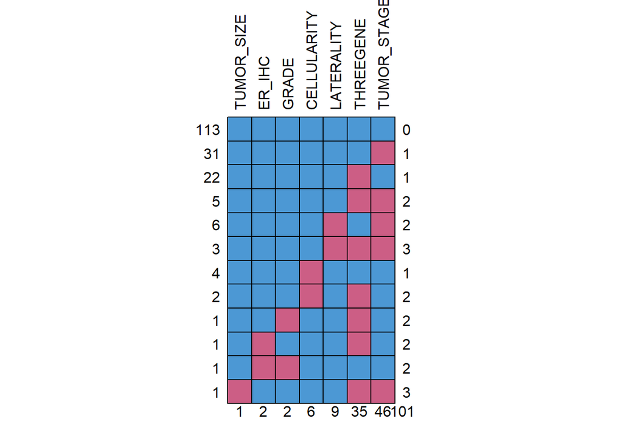

```
##     TUMOR_SIZE ER_IHC GRADE CELLULARITY LATERALITY THREEGENE TUMOR_STAGE
## 113          1      1     1           1          1         1           1   0
## 31           1      1     1           1          1         1           0   1
## 22           1      1     1           1          1         0           1   1
## 5            1      1     1           1          1         0           0   2
## 6            1      1     1           1          0         1           0   2
## 3            1      1     1           1          0         0           0   3
## 4            1      1     1           0          1         1           1   1
## 2            1      1     1           0          1         0           1   2
## 1            1      1     0           1          1         0           1   2
## 1            1      0     1           1          1         0           1   2
## 1            1      0     0           1          1         1           1   2
## 1            0      1     1           1          1         0           0   3
##              1      2     2           6          9        35          46 101
```

```r
na_vars <- miss_tab$variable
md.pattern(cl[, na_vars], rotate.names = TRUE)
```

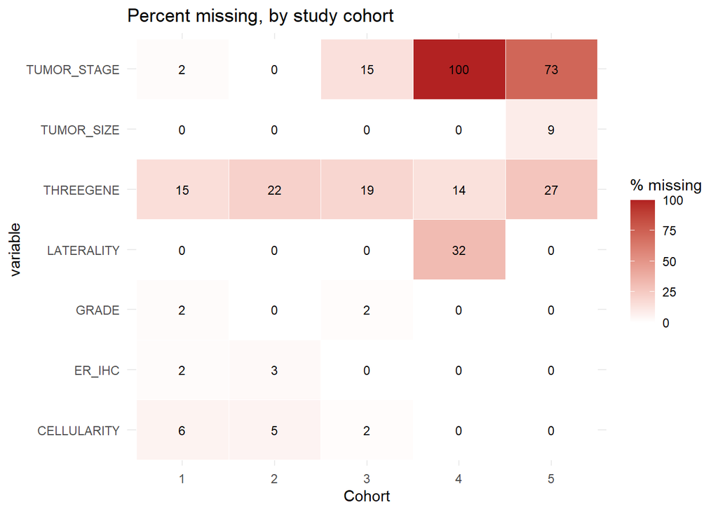

```r
cohort_miss <- do.call(rbind, lapply(na_vars, function(v)
  data.frame(variable = v, COHORT = sort(unique(cl$COHORT)),
             pct_missing = sapply(sort(unique(cl$COHORT)), function(k)
               100 * mean(is.na(cl[[v]][cl$COHORT == k]))))))
ggplot(cohort_miss, aes(factor(COHORT), variable, fill = pct_missing)) +
  geom_tile(colour = "white") +
  geom_text(aes(label = round(pct_missing)), size = 3) +
  scale_fill_gradient(low = "white", high = "firebrick") +
  labs(title = "Percent missing, by study cohort", x = "Cohort", fill = "% missing") +
  theme_minimal()
```

```r
p_cohort <- sapply(na_vars, function(v)
  fisher.test(table(is.na(cl[[v]]), cl$COHORT), simulate.p.value = TRUE, B = 5000)$p.value)
p_outcome <- sapply(na_vars, function(v)
  fisher.test(table(is.na(cl[[v]]), dat$y))$p.value)
round(data.frame(p_missing_vs_cohort = p_cohort, p_missing_vs_outcome = p_outcome), 4)
```

```
##             p_missing_vs_cohort p_missing_vs_outcome
## CELLULARITY              0.5583               0.0362
## ER_IHC                   0.6971               1.0000
## GRADE                    1.0000               0.5054
## LATERALITY               0.0002               0.1822
## THREEGENE                0.7944               0.0382
## TUMOR_SIZE               0.0612               0.4368
## TUMOR_STAGE              0.0002               0.3107
```

```r
table(THREEGENE_missing = is.na(dat$THREEGENE), dat$y)
```

```
##
## THREEGENE_missing Living Died
##             FALSE     93   62
##             TRUE      14   21
```

```r
prop.table(table(THREEGENE_missing = is.na(dat$THREEGENE), dat$y), margin = 2)
```

```
##
## THREEGENE_missing    Living      Died
##             FALSE 0.8691589 0.7469880
##             TRUE  0.1308411 0.2530120
```

```r
sum(is.na(cl$TUMOR_STAGE[cl$COHORT == 4])); sum(cl$COHORT == 4)
```

```
## [1] 28
```

```
## [1] 28
```

**Reading the pattern.**

- `TUMOR_STAGE` and `LATERALITY` are missing for essentially whole blocks of one cohort: all 28 cohort-4 patients have no stage (28 of 28), and every missing laterality value is also in cohort 4. This is **structural missingness**: that cohort never recorded these fields. It is not random across patients, but it depends on a variable I can see (the cohort), so it is *missing at random given the cohort*. It is ignorable for imputation only if the stage-versus-other-variables relationship is similar in cohort 4, which I cannot check because nobody in that cohort has a stage.
- `THREEGENE` is missing for 35 patients, spread over all cohorts. It is missing for 25.3% of the patients who died against 13.1% of those who lived (Fisher p = 0.038). This is a statistically notable link with the outcome, so the gaps are plausibly **not** missing at random: a tumour the classifier could not call may itself be a sign of a different disease.
- `CELLULARITY`, `ER_IHC`, `GRADE` and `TUMOR_SIZE` have only a handful of missing values each (at most 6) and look like ordinary scattered gaps.

# 3. Split first, then typed imputation

## Typing every variable correctly

```r
# level labels become column names later, so make them unique, plain ASCII names
# ("4ER-" and "4ER+" would otherwise both turn into "4ER.")
clean_lv <- function(f, signs = FALSE) {
  lv <- levels(f)
  if (signs) lv <- gsub("-", "neg", gsub("\\+", "pos", lv))
  levels(f) <- gsub("[^A-Za-z0-9]+", "_", lv)
  f
}
typed <- function(d) {
  out <- data.frame(
    AGE_AT_DIAGNOSIS = as.numeric(d$AGE_AT_DIAGNOSIS),
    NPI = as.numeric(d$NPI),
    TUMOR_SIZE = as.numeric(d$TUMOR_SIZE),
    MUTATION_COUNT = as.numeric(d$MUTATION_COUNT),
    GRADE = factor(ifelse(is.na(d$GRADE), NA, ifelse(d$GRADE == 3, "3", "1-2")),
                   levels = c("1-2", "3"), ordered = TRUE),
    TUMOR_STAGE = factor(ifelse(is.na(d$TUMOR_STAGE), NA,
                                ifelse(d$TUMOR_STAGE <= 1, "0-1", as.character(d$TUMOR_STAGE))),
                         levels = c("0-1", "2", "3"), ordered = TRUE),
    CELLULARITY = factor(d$CELLULARITY, levels = c("low", "moderate", "high"), ordered = TRUE),
    ER_IHC = factor(d$ER_IHC), LATERALITY = factor(d$LATERALITY),
    BREAST_SURGERY = factor(d$BREAST_SURGERY),
    INFERRED_MENOPAUSAL_STATE = factor(d$INFERRED_MENOPAUSAL_STATE),
    CLAUDIN_SUBTYPE = factor(d$CLAUDIN_SUBTYPE), HER2_SNP6 = factor(d$HER2_SNP6),
    INTCLUST = factor(d$INTCLUST), THREEGENE = factor(d$THREEGENE),
    COHORT = factor(d$COHORT))
  out$INTCLUST  <- clean_lv(out$INTCLUST, signs = TRUE)
  out$THREEGENE <- clean_lv(out$THREEGENE, signs = TRUE)
  out$CLAUDIN_SUBTYPE <- clean_lv(out$CLAUDIN_SUBTYPE)
  out$BREAST_SURGERY  <- clean_lv(out$BREAST_SURGERY)
  out
}
numeric_v <- c("AGE_AT_DIAGNOSIS", "NPI", "TUMOR_SIZE", "MUTATION_COUNT")
ordinal_v <- c("GRADE", "TUMOR_STAGE", "CELLULARITY")
nominal_v <- c("BREAST_SURGERY", "INFERRED_MENOPAUSAL_STATE", "LATERALITY", "ER_IHC",
               "CLAUDIN_SUBTYPE", "HER2_SNP6", "INTCLUST", "THREEGENE")
X <- typed(dat)
sapply(X, function(x) class(x)[1])
```

```
##          AGE_AT_DIAGNOSIS                       NPI                TUMOR_SIZE            MUTATION_COUNT
##                 "numeric"                 "numeric"                 "numeric"                 "numeric"
##                     GRADE               TUMOR_STAGE               CELLULARITY                    ER_IHC
##                 "ordered"                 "ordered"                 "ordered"                  "factor"
##                LATERALITY            BREAST_SURGERY INFERRED_MENOPAUSAL_STATE           CLAUDIN_SUBTYPE
##                  "factor"                  "factor"                  "factor"                  "factor"
##                 HER2_SNP6                  INTCLUST                 THREEGENE                    COHORT
##                  "factor"                  "factor"                  "factor"                  "factor"
```

```r
table(dat$GRADE, useNA = "ifany"); table(dat$TUMOR_STAGE, useNA = "ifany")
```

```
##
##    1    2    3 <NA>
##    2   17  169    2
```

```
##
##    0    1    2    3 <NA>
##    1   35   87   21   46
```

Grade 1 has 2 patients and stage 0 has 1 patient, too few for any model to learn, so I merged them into the next level (grade `1-2`, stage `0-1`). The ordering is kept, so both stay *ordered* factors, not numbers.

## Split first

```r
set.seed(2026)
s  <- sample.split(dat$y, SplitRatio = 0.7)      # stratified on the outcome
tr <- which(s); te <- which(!s)
rbind(train = table(dat$y[tr]), test = table(dat$y[te]))
```

```
##       Living Died
## train     75   58
## test      32   25
```

From here on, **nothing is learned from the test rows**: not an imputation model, not a mean, not a selected feature.

## Which imputer is better? A masking experiment on the training rows

To compare methods I hide 25% of the *known* stages in the training rows, impute them, and score the guesses against the truth.

```r
set.seed(7)
known <- which(!is.na(X$TUMOR_STAGE[tr]) & X$COHORT[tr] != "4")
base  <- X[tr, ]
lv    <- levels(base$TUMOR_STAGE)
score <- function(truth, guess_num) {
  g <- pmin(pmax(round(guess_num), 1), 3)
  c(acc = mean(g == as.integer(truth)), mae = mean(abs(guess_num - as.integer(truth))),
    nonint = mean(abs(guess_num - round(guess_num)) > 1e-9))
}
res <- do.call(rbind, lapply(1:10, function(i) {
  hide <- sample(known, round(0.25 * length(known)))
  d <- base; truth <- d$TUMOR_STAGE[hide]; d$TUMOR_STAGE[hide] <- NA
  mk <- function(method, dd) {
    mt <- make.method(dd); mt[] <- ""
    mt[colSums(is.na(dd)) > 0] <- "pmm"; mt["TUMOR_STAGE"] <- method
    for (v in c("GRADE", "CELLULARITY")) if (any(is.na(dd[[v]]))) mt[v] <- "polr"
    for (v in c("ER_IHC", "LATERALITY")) if (any(is.na(dd[[v]]))) mt[v] <- "logreg"
    if (any(is.na(dd$THREEGENE))) mt["THREEGENE"] <- "cart"
    # mice's polr/logreg fail when a variable has exactly one gap: use a tree there
    one <- names(mt)[colSums(is.na(dd)) == 1 & !names(mt) %in% c("TUMOR_STAGE", numeric_v)]
    mt[one] <- "cart"
    mt[colSums(is.na(dd)) == 0] <- ""
    mt
  }
  # (a) treated as continuous
  dn <- d; dn$TUMOR_STAGE <- as.numeric(dn$TUMOR_STAGE)
  gn <- suppressWarnings(mice::complete(mice(dn, m = 1, maxit = 5, method = mk("norm", dn),
                                       printFlag = FALSE, seed = i), 1))$TUMOR_STAGE[hide]
  # (b) ordered factor with proportional odds
  go <- suppressWarnings(mice::complete(mice(d, m = 1, maxit = 5, method = mk("polr", d),
                                       printFlag = FALSE, seed = i), 1))$TUMOR_STAGE[hide]
  # (b2) random-forest imputation inside mice (still typed: it sees an ordered factor)
  gr <- suppressWarnings(mice::complete(mice(d, m = 1, maxit = 5, method = mk("rf", d), ntrees = 100,
                                       printFlag = FALSE, seed = i), 1))$TUMOR_STAGE[hide]
  # (c) missForest
  gf <- suppressWarnings(missForest(d, ntree = 100, verbose = FALSE)$ximp)$TUMOR_STAGE[hide]
  # (d) mode
  md <- names(which.max(table(d$TUMOR_STAGE)))
  rbind(data.frame(method = "treated as continuous (norm)", t(score(truth, gn))),
        data.frame(method = "mice polr (ordered factor)", t(score(truth, as.integer(go)))),
        data.frame(method = "mice rf (random forest)", t(score(truth, as.integer(gr)))),
        data.frame(method = "missForest", t(score(truth, as.integer(gf)))),
        data.frame(method = "most common level", t(score(truth, rep(match(md, lv), length(hide))))))
}))
mask_summary <- aggregate(cbind(acc, mae, nonint) ~ method, data = res, FUN = mean)
mask_summary[, -1] <- round(mask_summary[, -1], 3)
names(mask_summary) <- c("method", "exact_match", "mean_abs_error_in_stages", "share_non_integer")
mask_summary[order(-mask_summary$exact_match), ]
```

```
##                         method exact_match mean_abs_error_in_stages share_non_integer
## 3                   missForest       0.769                    0.238                 0
## 2      mice rf (random forest)       0.669                    0.335                 0
## 4            most common level       0.608                    0.392                 0
## 1   mice polr (ordered factor)       0.538                    0.496                 0
## 5 treated as continuous (norm)       0.481                    0.685                 1
```

```r
# pick the best method that can be fitted on training rows only and applied to new rows
em <- setNames(mask_summary$exact_match, mask_summary$method)
stage_method <- if (em["mice rf (random forest)"] > em["mice polr (ordered factor)"]) "rf" else "polr"
stage_method
```

```
## [1] "rf"
```

`missForest` scored highest, but it has no way to fill new rows from a model it learned (the test rows would have to take part in fitting it), so it cannot be used in a split-first pipeline. Among methods that **can** be fitted on the training rows and applied to the test rows (`mice` with the `ignore` argument), the best for `TUMOR_STAGE` is **`mice` with rf** (67% exact match, against 61% for always guessing the most common stage). I use that for `TUMOR_STAGE`, and keep `polr` for the other ordered variables, which have only a handful of gaps and are too few to test the same way.

## Typed imputation with mice, learned on the training rows only

Each variable with gaps gets the method that matches its type. `mice`’s `ignore` argument keeps the test rows out of every model fit while still filling their gaps from models trained on the training rows.

```r
st   <- rbind(X[tr, ], X[te, ])
ign  <- c(rep(FALSE, length(tr)), rep(TRUE, length(te)))
meth <- make.method(st); meth[] <- ""
meth[numeric_v]                     <- "pmm"      # numeric: predictive mean matching
meth[c("GRADE", "CELLULARITY")]     <- "polr"    # ordered factor: proportional odds
meth["TUMOR_STAGE"]                 <- stage_method  # chosen by the masking experiment above
meth[c("ER_IHC", "LATERALITY")]     <- "logreg"   # two-level factor: logistic regression
meth["THREEGENE"]                   <- "cart"     # sparse 4-level factor: classification tree
meth[colSums(is.na(st)) == 0]       <- ""         # nothing to impute
meth[meth != ""]
```

```
##  TUMOR_SIZE       GRADE TUMOR_STAGE CELLULARITY      ER_IHC  LATERALITY   THREEGENE
##       "pmm"      "polr"        "rf"      "polr"    "logreg"    "logreg"      "cart"
```

```r
imp <- suppressWarnings(mice(st, m = 5, maxit = 10, method = meth, ntrees = 100,
                             predictorMatrix = make.predictorMatrix(st),
                             ignore = ign, seed = 1, printFlag = FALSE))
Xc <- mice::complete(imp, 1)
c(remaining_NA = sum(is.na(Xc)))
```

```
## remaining_NA
##            0
```

```r
Xc_tr <- Xc[seq_along(tr), ]; Xc_te <- Xc[-seq_along(tr), ]
```

**How stable are the imputed values?** With five imputations, this is the share of missing cells where all five draws agree.

```r
agree <- sapply(names(meth[meth != ""]), function(v) {
  m <- imp$imp[[v]]
  if (is.null(m) || nrow(m) == 0) return(NA)
  mean(apply(m, 1, function(r) length(unique(r)) == 1))
})
data.frame(variable = names(agree), method = meth[names(agree)],
           n_imputed = sapply(names(agree), function(v) nrow(imp$imp[[v]])),
           pct_all_five_agree = round(100 * agree))
```

```
##                variable method n_imputed pct_all_five_agree
## TUMOR_SIZE   TUMOR_SIZE    pmm         1                  0
## GRADE             GRADE   polr         2                100
## TUMOR_STAGE TUMOR_STAGE     rf        46                 39
## CELLULARITY CELLULARITY   polr         6                  0
## ER_IHC           ER_IHC logreg         2                  0
## LATERALITY   LATERALITY logreg         9                 33
## THREEGENE     THREEGENE   cart        35                 80
```

One warning about `TUMOR_STAGE`: because every cohort-4 patient is missing stage, the observed stages carry no information about how cohort 4 differs (the cohort is not a usable predictor for it). Those patients’ stage is predicted from their other variables only, and my masking experiment (which hid stages only in the other cohorts) cannot show how well that works for cohort 4.

# 4. Leakage audit

The question for each candidate: **would this value be known, and would it be unaffected by the outcome, at the tumour-board moment defined above?**

```r
audit <- data.frame(
  variable = c("AGE_AT_DIAGNOSIS", "BREAST_SURGERY", "CELLULARITY", "GRADE",
               "INFERRED_MENOPAUSAL_STATE", "LATERALITY", "NPI", "TUMOR_SIZE", "TUMOR_STAGE",
               "ER_IHC", "CLAUDIN_SUBTYPE", "HER2_SNP6", "MUTATION_COUNT", "INTCLUST",
               "THREEGENE", "18 gene mutation flags", "COHORT",
               "OS_MONTHS", "VITAL_STATUS", "CHEMOTHERAPY", "HORMONE_THERAPY", "RADIO_THERAPY"),
  known_when = c("At diagnosis", "At surgery", "Pathology after surgery", "Pathology after surgery",
                 "At diagnosis", "At diagnosis", "Pathology (size, grade, nodes)",
                 "Pathology after surgery", "Pathology after surgery", "Pathology after surgery",
                 "Tumour expression profiling", "Tumour copy-number profiling",
                 "Tumour sequencing", "Tumour copy-number and expression profiling",
                 "Tumour expression profiling", "Tumour sequencing",
                 "Which study the patient joined",
                 "Years of follow-up after the decision", "End of follow-up",
                 "After the board decides", "After the board decides", "After the board decides"),
  known_at_moment = c(rep("yes", 17), "no", "no (it is the label)", "no", "no", "no"),
  verdict = c(rep("keep", 16), "keep as imputation helper only, not a predictor",
              "remove: leakage", "label", "remove: leakage", "remove: leakage", "remove: leakage"),
  stringsAsFactors = FALSE)
knitr::kable(audit)
```

| variable | known_when | known_at_moment | verdict |
| --- | --- | --- | --- |
| AGE_AT_DIAGNOSIS | At diagnosis | yes | keep |
| BREAST_SURGERY | At surgery | yes | keep |
| CELLULARITY | Pathology after surgery | yes | keep |
| GRADE | Pathology after surgery | yes | keep |
| INFERRED_MENOPAUSAL_STATE | At diagnosis | yes | keep |
| LATERALITY | At diagnosis | yes | keep |
| NPI | Pathology (size, grade, nodes) | yes | keep |
| TUMOR_SIZE | Pathology after surgery | yes | keep |
| TUMOR_STAGE | Pathology after surgery | yes | keep |
| ER_IHC | Pathology after surgery | yes | keep |
| CLAUDIN_SUBTYPE | Tumour expression profiling | yes | keep |
| HER2_SNP6 | Tumour copy-number profiling | yes | keep |
| MUTATION_COUNT | Tumour sequencing | yes | keep |
| INTCLUST | Tumour copy-number and expression profiling | yes | keep |
| THREEGENE | Tumour expression profiling | yes | keep |
| 18 gene mutation flags | Tumour sequencing | yes | keep |
| COHORT | Which study the patient joined | yes | keep as imputation helper only, not a predictor |
| OS_MONTHS | Years of follow-up after the decision | no | remove: leakage |
| VITAL_STATUS | End of follow-up | no (it is the label) | label |
| CHEMOTHERAPY | After the board decides | no | remove: leakage |
| HORMONE_THERAPY | After the board decides | no | remove: leakage |
| RADIO_THERAPY | After the board decides | no | remove: leakage |

Notes on the judgement calls:

- **Genomic variables** are legitimate only if tumour profiling has been done before the decision. I assume it has (it is also what next week’s TNBC model needs), but it would not be true for a clinic without sequencing.
- **`NPI`** is derived from size, grade and nodal status, so it is known after pathology, but it largely repeats `TUMOR_SIZE` and `GRADE`; the correlation step below deals with that, not leakage.
- **`COHORT`** is known at the time but is a study artefact (site and period), not biology; I use it only to help imputation, never as a predictor.
- **Treatment** variables record decisions made *after* the moment: a model using them would be reading the board’s own view of the prognosis.

## A statistical filter would pick the leaky variables

This is the check that shows why leakage is a separate problem from statistical selection. Information gain (in bits) on the training rows, for the leaky variables and for the best legitimate ones:

```r
H <- function(p) { p <- p[p > 0]; -sum(p * log2(p)) }
ig1 <- function(x, y) {
  if (is.numeric(x) && length(unique(x)) > 2) {
    br <- unique(quantile(x, 0:4 / 4, na.rm = TRUE))
    x <- cut(x, br, include.lowest = TRUE)
  }
  tab <- table(x, y); px <- rowSums(tab) / sum(tab)
  H(prop.table(table(y))) - sum(px * apply(tab, 1, function(r) H(r / sum(r))))
}
ytr <- dat$y[tr]
leaky <- data.frame(OS_MONTHS = dat$OS_MONTHS, CHEMOTHERAPY = dat$CHEMOTHERAPY,
                    HORMONE_THERAPY = dat$HORMONE_THERAPY)[tr, ]
legit <- cbind(Xc_tr[, c("NPI", "TUMOR_SIZE", "GRADE", "TUMOR_STAGE", "AGE_AT_DIAGNOSIS")],
               dat[tr, c("TP53", "PIK3CA")])
ig_compare <- c(sapply(leaky, ig1, y = ytr), sapply(as.data.frame(lapply(legit, function(z) if (is.ordered(z)) as.integer(z) else z)), ig1, y = ytr))
data.frame(variable = names(ig_compare), info_gain_bits = round(ig_compare, 3),
           type = c(rep("leaky", ncol(leaky)), rep("legitimate", ncol(legit))))[order(-ig_compare), ]
```

```
##                          variable info_gain_bits       type
## OS_MONTHS               OS_MONTHS          0.452      leaky
## NPI                           NPI          0.049 legitimate
## TUMOR_SIZE             TUMOR_SIZE          0.045 legitimate
## TUMOR_STAGE           TUMOR_STAGE          0.019 legitimate
## AGE_AT_DIAGNOSIS AGE_AT_DIAGNOSIS          0.014 legitimate
## HORMONE_THERAPY   HORMONE_THERAPY          0.005      leaky
## TP53                         TP53          0.002 legitimate
## CHEMOTHERAPY         CHEMOTHERAPY          0.001      leaky
## GRADE                       GRADE          0.000 legitimate
## PIK3CA                     PIK3CA          0.000 legitimate
```

`OS_MONTHS` carries far more information about the outcome than any legitimate predictor, because survival time and vital status are two sides of the same event. It would be selected first by any data-driven filter, which is why it has to be removed by *reasoning*, before the statistics.

# 5. TNBC feature pipeline (learned on the training rows only)

Candidate predictors after the domain and leakage decisions: 10 clinical, 5 genomic summary variables and 18 gene flags. The test rows get the *same* transformations, never refitted.

## Encoding

- Numeric variables stay numeric.
- Ordered factors become integer codes that respect the order.
- Nominal factors become one-hot columns (`fullRank`, so one level is the baseline).
- Gene flags are already 0/1.

```r
make_feat <- function(Xcomp, rows) {
  f <- Xcomp[, c(numeric_v, ordinal_v, nominal_v)]
  for (o in ordinal_v) f[[o]] <- as.integer(f[[o]])
  cbind(f, dat[rows, genes])
}
feat_tr <- make_feat(Xc_tr, tr); feat_te <- make_feat(Xc_te, te)
dv  <- dummyVars(~ ., data = feat_tr, fullRank = TRUE)
Etr <- predict(dv, feat_tr); Ete <- predict(dv, feat_te)
colnames(Etr) <- colnames(Ete) <- make.names(colnames(Etr), unique = TRUE)
stopifnot(!anyDuplicated(colnames(Etr)))
c(encoded_columns = ncol(Etr), train_rows = nrow(Etr), test_rows = nrow(Ete))
```

```
## encoded_columns      train_rows       test_rows
##              46             133              57
```

```r
all_vars <- c(numeric_v, ordinal_v, nominal_v, genes)
map_var <- function(cols) sapply(cols, function(cn) {
  hit <- all_vars[startsWith(cn, all_vars)]
  hit[which.max(nchar(hit))]
})
col_var <- map_var(colnames(Etr))
```

## Step 1: near-zero variance, then scaling

```r
nz <- nearZeroVar(Etr, saveMetrics = TRUE)
keep_nzv <- rownames(nz)[!nz$nzv]
Etr1 <- Etr[, keep_nzv]; Ete1 <- Ete[, keep_nzv]
c(before = ncol(Etr), after_nzv = ncol(Etr1))
```

```
##    before after_nzv
##        46        29
```

```r
# scaling parameters come from the TRAINING rows only
pp  <- preProcess(Etr1, method = c("center", "scale"))
Str <- predict(pp, Etr1); Ste <- predict(pp, Ete1)
round(c(train_mean_NPI = mean(Str[, "NPI"]), test_mean_NPI = mean(Ste[, "NPI"]),
        train_sd_NPI = sd(Str[, "NPI"]), test_sd_NPI = sd(Ste[, "NPI"])), 3)
```

```
## train_mean_NPI  test_mean_NPI   train_sd_NPI    test_sd_NPI
##          0.000         -0.044          1.000          1.065
```

Columns with near-zero variance (here, mostly rare mutations) are dropped. The test set is *not* exactly mean 0, SD 1: that is correct, it was scaled with the training numbers.

## Step 2: correlation

```r
cm <- cor(Str)
pairs <- which(upper.tri(cm), arr.ind = TRUE)
top <- data.frame(a = colnames(cm)[pairs[, 1]], b = colnames(cm)[pairs[, 2]], r = cm[pairs])
top <- top[order(-abs(top$r)), ]
head(top, 8)
```

```
##                    a                             b          r
## 29  AGE_AT_DIAGNOSIS INFERRED_MENOPAUSAL_STATE.pre -0.8122598
## 147       ER_IHC.pos               INTCLUST.4ERpos  0.6196773
## 105   HER2_SNP6.LOSS                HER2_SNP6.NEUT -0.6076522
## 12               NPI                   TUMOR_STAGE  0.5593700
## 8                NPI                         GRADE  0.5528499
## 50             GRADE                    ER_IHC.pos -0.5337040
## 136      INTCLUST.10               INTCLUST.4ERneg -0.4777892
## 330            GRADE                          TP53  0.4109796
```

```r
# Tie-break by domain knowledge: menopausal state is *inferred from age*, so when the
# two are highly correlated I drop the derived variable and keep age (the richer one).
drop_derived <- if (abs(cm["AGE_AT_DIAGNOSIS", "INFERRED_MENOPAUSAL_STATE.pre"]) > 0.8)
  "INFERRED_MENOPAUSAL_STATE.pre" else character(0)
rest <- setdiff(colnames(cm), drop_derived)
corr_drop <- c(drop_derived, findCorrelation(cm[rest, rest], cutoff = 0.8, names = TRUE))
corr_drop
```

```
## [1] "INFERRED_MENOPAUSAL_STATE.pre"
```

```r
keep_corr <- setdiff(colnames(Str), corr_drop)
```

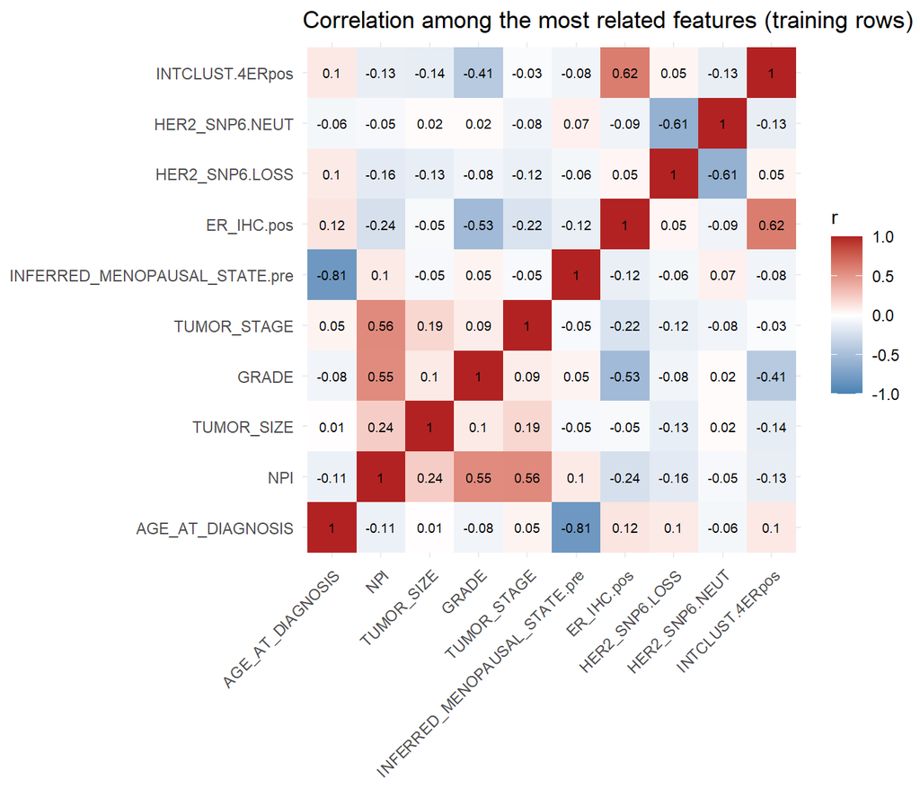

```r
cm_long <- as.data.frame(as.table(cm)); names(cm_long) <- c("a", "b", "r")
top_cols <- unique(c(head(top$a, 6), head(top$b, 6), "NPI", "TUMOR_STAGE", "GRADE", "TUMOR_SIZE"))
top_cols <- intersect(top_cols, colnames(cm))
ggplot(subset(cm_long, a %in% top_cols & b %in% top_cols), aes(a, b, fill = r)) +
  geom_tile() + geom_text(aes(label = round(r, 2)), size = 2.5) +
  scale_fill_gradient2(low = "steelblue", mid = "white", high = "firebrick", limits = c(-1, 1)) +
  labs(title = "Correlation among the most related features (training rows)", x = NULL, y = NULL) +
  theme_minimal() + theme(axis.text.x = element_text(angle = 45, hjust = 1))
```

## Step 3: information gain (with a permutation null)

For each remaining column I compute the information gain about the outcome (in bits, numeric columns cut into quartiles) and compare it with the gain I would get from the same column if the outcome labels were shuffled. A column is kept only if its real gain exceeds the 95th percentile of its own shuffled gains.

```r
ig_vec <- function(M, y) sapply(seq_len(ncol(M)), function(j) ig1(M[, j], y))
set.seed(11)
M <- Etr1[, keep_corr, drop = FALSE]
ig_real <- ig_vec(M, ytr)
null <- replicate(300, ig_vec(M, sample(ytr)))
ig_thr <- apply(null, 1, quantile, probs = 0.95)
ig_tab <- data.frame(column = colnames(M), variable = col_var[colnames(M)],
                     info_gain = ig_real, null_95 = ig_thr, keep = ig_real > ig_thr)
ig_tab <- ig_tab[order(-ig_tab$info_gain), ]
rownames(ig_tab) <- NULL
ig_keep <- ig_tab$column[ig_tab$keep]
head(ig_tab, 12)
```

```
##                       column         variable  info_gain    null_95  keep
## 1                     SHANK2           SHANK2 0.05865287 0.01199050  TRUE
## 2  BREAST_SURGERY.MASTECTOMY   BREAST_SURGERY 0.05273444 0.02286227  TRUE
## 3                        NPI              NPI 0.04851989 0.04345711  TRUE
## 4                 TUMOR_SIZE       TUMOR_SIZE 0.04549333 0.04393967  TRUE
## 5                     MAP3K1           MAP3K1 0.03872146 0.02089412  TRUE
## 6       CLAUDIN_SUBTYPE.Her2  CLAUDIN_SUBTYPE 0.03595974 0.02088594  TRUE
## 7                      NCOR2            NCOR2 0.02089412 0.02089412 FALSE
## 8                INTCLUST.10         INTCLUST 0.01972178 0.02275247 FALSE
## 9                TUMOR_STAGE      TUMOR_STAGE 0.01857547 0.01857547 FALSE
## 10                     SYNE1            SYNE1 0.01530490 0.01898087 FALSE
## 11          AGE_AT_DIAGNOSIS AGE_AT_DIAGNOSIS 0.01410337 0.04218911 FALSE
## 12                    DNAH11           DNAH11 0.01198173 0.02240699 FALSE
```

```r
c(tested = nrow(ig_tab), kept = length(ig_keep))
```

```
## tested   kept
##     28      6
```

## Step 4: recursive feature elimination (RFE)

```r
set.seed(13)
xr <- as.data.frame(Str[, ig_keep, drop = FALSE])
sizes <- sort(unique(pmin(c(2, 3, 4, 5, 6, 8, 10, 12, 15, 20), ncol(xr))))
ctrl <- rfeControl(functions = rfFuncs, method = "repeatedcv", number = 5, repeats = 3)
rfe_fit <- rfe(x = xr, y = ytr, sizes = sizes, rfeControl = ctrl, ntree = 300)
rfe_sel <- predictors(rfe_fit)
rfe_fit$results[, c("Variables", "Accuracy", "Kappa")]
```

```
##   Variables  Accuracy     Kappa
## 1         2 0.6037987 0.1810965
## 2         3 0.6592593 0.2921902
## 3         4 0.6345679 0.2551021
## 4         5 0.6870845 0.3540518
## 5         6 0.6842355 0.3458948
```

```r
rfe_sel
```

```
## [1] "NPI"                       "TUMOR_SIZE"                "BREAST_SURGERY.MASTECTOMY"
## [4] "SHANK2"                    "MAP3K1"
```

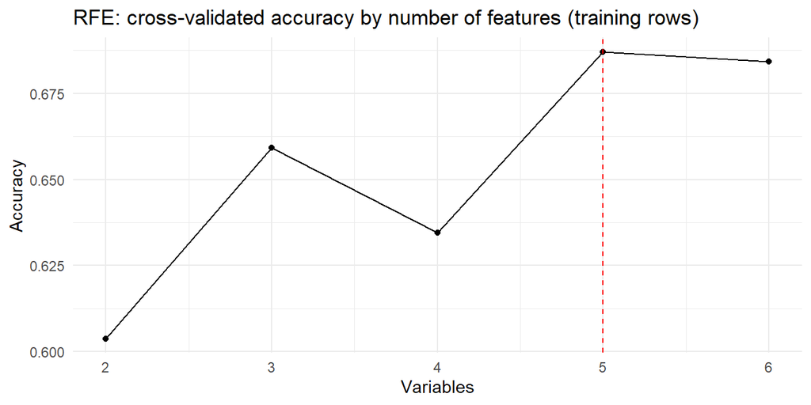

```r
ggplot(rfe_fit$results, aes(Variables, Accuracy)) + geom_line() + geom_point() +
  geom_vline(xintercept = length(rfe_sel), linetype = "dashed", colour = "red") +
  labs(title = "RFE: cross-validated accuracy by number of features (training rows)") +
  theme_minimal()
```

RFE picks the smallest subset whose cross-validated accuracy is within 1.5% of the best, which gives **5 features**.

```r
auc <- function(score, y) {
  r <- rank(score); n1 <- sum(y == "Died"); n0 <- sum(y == "Living")
  (sum(r[y == "Died"]) - n1 * (n1 + 1) / 2) / (n1 * n0)
}
yte <- dat$y[te]
set.seed(5)
rf_all <- randomForest(x = as.data.frame(Str[, keep_nzv]), y = ytr, ntree = 500)
rf_sel <- randomForest(x = as.data.frame(Str[, rfe_sel, drop = FALSE]), y = ytr, ntree = 500)
data.frame(features = c(ncol(Str), length(rfe_sel)),
           test_AUC = round(c(auc(predict(rf_all, as.data.frame(Ste), type = "prob")[, "Died"], yte),
                              auc(predict(rf_sel, as.data.frame(Ste[, rfe_sel, drop = FALSE]), type = "prob")[, "Died"], yte)), 3),
           row.names = c("all columns after near-zero-variance filter", "RFE-selected"))
```

```
##                                             features test_AUC
## all columns after near-zero-variance filter       29    0.644
## RFE-selected                                       5    0.623
```

This is only a sanity check that the pipeline runs end to end on held-out rows (the test set has only 57 patients, so differences of a few points mean nothing); the four-model comparison is next week’s job.

## Step 5: principal components

PCA is fitted on the **scaled training** features after the correlation filter, and the test rows are projected with the same rotation.

```r
pca <- prcomp(Str[, keep_corr], center = FALSE, scale. = FALSE)
ve <- summary(pca)$importance
round(ve[, 1:6], 3)
```

```
##                          PC1   PC2   PC3   PC4   PC5   PC6
## Standard deviation     1.919 1.540 1.458 1.353 1.305 1.196
## Proportion of Variance 0.131 0.085 0.076 0.065 0.061 0.051
## Cumulative Proportion  0.131 0.216 0.292 0.357 0.418 0.469
```

```r
pcs_te <- predict(pca, Ste[, keep_corr])
load_top <- function(k, n = 8) {
  l <- pca$rotation[, k]; l[order(-abs(l))][1:n]
}
round(load_top(1), 3)
```

```
##      ER_IHC.pos     INTCLUST.10           GRADE     CELLULARITY INTCLUST.4ERpos            TP53
##          -0.362           0.362           0.352           0.328          -0.325           0.292
##           GATA3             NPI
##           0.232           0.198
```

```r
round(load_top(2), 3)
```

```
##               TUMOR_STAGE                       NPI BREAST_SURGERY.MASTECTOMY                     BIRC6
##                     0.469                     0.444                     0.423                    -0.249
##                     SYNE1            MUTATION_COUNT                TUMOR_SIZE                     GRADE
##                    -0.242                    -0.227                     0.221                     0.167
```

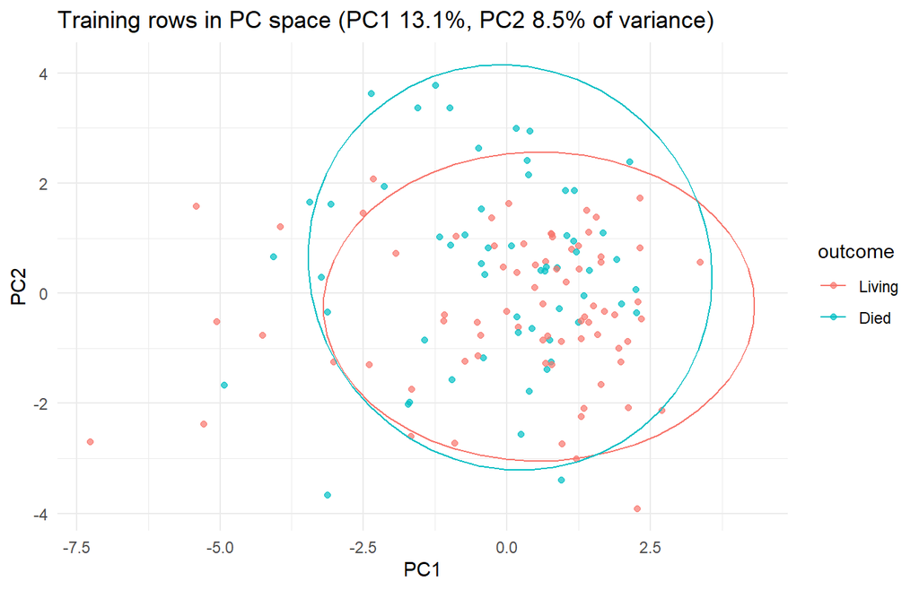

```r
sc <- data.frame(PC1 = pca$x[, 1], PC2 = pca$x[, 2], outcome = ytr)
ggplot(sc, aes(PC1, PC2, colour = outcome)) + geom_point(alpha = 0.7) +
  stat_ellipse() +
  labs(title = paste0("Training rows in PC space (PC1 ", round(100 * ve[2, 1], 1),
                      "%, PC2 ", round(100 * ve[2, 2], 1), "% of variance)")) +
  theme_minimal()
```

```r
# How much would the rotation change if PCA had been fitted on ALL rows (the leak)?
S_all <- rbind(Str[, keep_corr], Ste[, keep_corr])
pca_all <- prcomp(S_all, center = FALSE, scale. = FALSE)
cos1 <- abs(sum(pca$rotation[, 1] * pca_all$rotation[, 1]))
cos2 <- abs(sum(pca$rotation[, 2] * pca_all$rotation[, 2]))
c(cosine_PC1_train_vs_all = round(cos1, 4), cosine_PC2_train_vs_all = round(cos2, 4),
  test_rows_PC1_mean_trainfit = round(mean(pcs_te[, 1]), 3),
  test_rows_PC1_mean_allfit = round(mean(predict(pca_all, Ste[, keep_corr])[, 1]), 3))
```

```
##     cosine_PC1_train_vs_all     cosine_PC2_train_vs_all test_rows_PC1_mean_trainfit
##                      0.9855                      0.8698                     -0.0780
##   test_rows_PC1_mean_allfit
##                      0.1140
```

# 6. Table of removed variables

One row per removed variable: its reason (**domain exclusion**, **leakage prevention** or **statistical selection**) and a sentence of justification. The statistical sentences are generated from the numbers above.

```r
# ---- statistical selection: stage at which each variable's LAST column is removed
col_stage <- rep("kept", ncol(Etr)); names(col_stage) <- colnames(Etr)
col_stage[!colnames(Etr) %in% keep_nzv] <- "nzv"
col_stage[colnames(Etr) %in% corr_drop] <- "correlation"
col_stage[colnames(Etr) %in% setdiff(keep_corr, ig_keep)] <- "info_gain"
col_stage[colnames(Etr) %in% setdiff(ig_keep, rfe_sel)] <- "rfe"
order_st <- c(nzv = 1, correlation = 2, info_gain = 3, rfe = 4)

stat_rows <- do.call(rbind, lapply(unique(col_var), function(v) {
  cols <- names(col_var)[col_var == v]
  st <- col_stage[cols]
  if (any(st == "kept")) return(NULL)               # at least one column survives
  last <- names(which.max(order_st[st]))
  cl_last <- cols[st == last]
  sentence <- switch(last,
    nzv = {
      if (v %in% genes) sprintf("Mutated in only %d of %d training patients (%.1f%%), too few events to learn from.",
                                sum(feat_tr[[v]]), nrow(feat_tr), 100 * mean(feat_tr[[v]]))
      else sprintf("One value covers %.0f%% of the training patients, so it adds almost no information.",
                   100 * max(prop.table(table(feat_tr[[v]]))))
    },
    correlation = {
      cc <- cl_last[1]
      others <- setdiff(keep_corr, cc)
      rr <- cm[cc, others]; nm <- names(which.max(abs(rr)))
      sprintf("Correlated r = %.2f with %s, so it repeats information that variable already carries.", rr[nm], nm)
    },
    info_gain = {
      ii <- ig_tab[ig_tab$column %in% cl_last, ]
      sprintf("Information gain %.4f bits, not above the %.4f bits it reaches with shuffled outcomes, so no real signal.",
              max(ii$info_gain), ii$null_95[which.max(ii$info_gain)])
    },
    rfe = sprintf("Dropped by RFE: the best %d-feature subset scored within 1.5%% of the top cross-validated accuracy without it.", length(rfe_sel)))
  data.frame(variable = v, reason = "statistical selection",
             justification = sprintf("%s (stage: %s)", sentence,
                                     c(nzv = "near-zero variance", correlation = "correlation filter",
                                       info_gain = "information gain", rfe = "RFE")[last]))
}))

# ---- domain exclusions and leakage prevention (decided before looking at the data)
dom <- data.frame(
  variable = c("PATIENT_ID", "CANCER_TYPE", "SAMPLE_TYPE", "ER_STATUS", "PR_STATUS", "HER2_STATUS",
               "CANCER_TYPE_DETAILED", "HISTOLOGICAL_SUBTYPE", "ONCOTREE_CODE", "COHORT"),
  reason = "domain exclusion",
  justification = c(
    "A row identifier carries no biology and would let a model memorise patients.",
    "Every patient has 'Breast Cancer', so it cannot separate anyone.",
    "Every patient has a 'Primary' sample, so it cannot separate anyone.",
    "'-' for all 190 patients because TNBC is defined by negative ER, so it is constant by construction.",
    "'-' for all 190 patients because TNBC is defined by negative PR, so it is constant by construction.",
    "'-' for all 190 patients because TNBC is defined by negative HER2, so it is constant by construction.",
    "One of three overlapping histology vocabularies for the same tumours; the labels also differ by cohort coding.",
    "A second histology vocabulary overlapping the other two; kept out to avoid triple-counting one fact.",
    "A third histology vocabulary overlapping the other two; kept out to avoid triple-counting one fact.",
    "Study site and period, not biology; a model could learn 'which cohort' as a shortcut for follow-up length. Used only to help imputation."),
  stringsAsFactors = FALSE)
leak <- data.frame(
  variable = c("OS_MONTHS", "VITAL_STATUS", "CHEMOTHERAPY", "HORMONE_THERAPY", "RADIO_THERAPY"),
  reason = "leakage prevention",
  justification = c(
    "Survival time is the outcome measured another way, and it has far more information gain than any legitimate predictor.",
    "This is the label itself.",
    "Decided after the prediction moment, and chosen by clinicians who already judge prognosis.",
    "Decided after the prediction moment, and chosen by clinicians who already judge prognosis.",
    "Decided after the prediction moment (and 'YES' for every patient here, so also constant)."),
  stringsAsFactors = FALSE)

removed <- rbind(dom, leak, stat_rows)
rownames(removed) <- NULL
removed <- removed[order(factor(removed$reason, levels = c("domain exclusion", "leakage prevention", "statistical selection"))), ]
rownames(removed) <- NULL
table(removed$reason)
```

```
##
##      domain exclusion    leakage prevention statistical selection
##                    10                     5                    28
```

```r
knitr::kable(removed)
```

| variable | reason | justification |
| --- | --- | --- |
| PATIENT_ID | domain exclusion | A row identifier carries no biology and would let a model memorise patients. |
| CANCER_TYPE | domain exclusion | Every patient has ‘Breast Cancer’, so it cannot separate anyone. |
| SAMPLE_TYPE | domain exclusion | Every patient has a ‘Primary’ sample, so it cannot separate anyone. |
| ER_STATUS | domain exclusion | ‘-’ for all 190 patients because TNBC is defined by negative ER, so it is constant by construction. |
| PR_STATUS | domain exclusion | ‘-’ for all 190 patients because TNBC is defined by negative PR, so it is constant by construction. |
| HER2_STATUS | domain exclusion | ‘-’ for all 190 patients because TNBC is defined by negative HER2, so it is constant by construction. |
| CANCER_TYPE_DETAILED | domain exclusion | One of three overlapping histology vocabularies for the same tumours; the labels also differ by cohort coding. |
| HISTOLOGICAL_SUBTYPE | domain exclusion | A second histology vocabulary overlapping the other two; kept out to avoid triple-counting one fact. |
| ONCOTREE_CODE | domain exclusion | A third histology vocabulary overlapping the other two; kept out to avoid triple-counting one fact. |
| COHORT | domain exclusion | Study site and period, not biology; a model could learn ‘which cohort’ as a shortcut for follow-up length. Used only to help imputation. |
| OS_MONTHS | leakage prevention | Survival time is the outcome measured another way, and it has far more information gain than any legitimate predictor. |
| VITAL_STATUS | leakage prevention | This is the label itself. |
| CHEMOTHERAPY | leakage prevention | Decided after the prediction moment, and chosen by clinicians who already judge prognosis. |
| HORMONE_THERAPY | leakage prevention | Decided after the prediction moment, and chosen by clinicians who already judge prognosis. |
| RADIO_THERAPY | leakage prevention | Decided after the prediction moment (and ‘YES’ for every patient here, so also constant). |
| AGE_AT_DIAGNOSIS | statistical selection | Information gain 0.0141 bits, not above the 0.0422 bits it reaches with shuffled outcomes, so no real signal. (stage: information gain) |
| MUTATION_COUNT | statistical selection | Information gain 0.0029 bits, not above the 0.0446 bits it reaches with shuffled outcomes, so no real signal. (stage: information gain) |
| GRADE | statistical selection | Information gain 0.0005 bits, not above the 0.0225 bits it reaches with shuffled outcomes, so no real signal. (stage: information gain) |
| TUMOR_STAGE | statistical selection | Information gain 0.0186 bits, not above the 0.0186 bits it reaches with shuffled outcomes, so no real signal. (stage: information gain) |
| CELLULARITY | statistical selection | Information gain 0.0031 bits, not above the 0.0235 bits it reaches with shuffled outcomes, so no real signal. (stage: information gain) |
| INFERRED_MENOPAUSAL_STATE | statistical selection | Correlated r = -0.81 with AGE_AT_DIAGNOSIS, so it repeats information that variable already carries. (stage: correlation filter) |
| LATERALITY | statistical selection | Information gain 0.0006 bits, not above the 0.0238 bits it reaches with shuffled outcomes, so no real signal. (stage: information gain) |
| ER_IHC | statistical selection | Information gain 0.0039 bits, not above the 0.0190 bits it reaches with shuffled outcomes, so no real signal. (stage: information gain) |
| CLAUDIN_SUBTYPE | statistical selection | Dropped by RFE: the best 5-feature subset scored within 1.5% of the top cross-validated accuracy without it. (stage: RFE) |
| HER2_SNP6 | statistical selection | Information gain 0.0026 bits, not above the 0.0229 bits it reaches with shuffled outcomes, so no real signal. (stage: information gain) |
| INTCLUST | statistical selection | Information gain 0.0197 bits, not above the 0.0228 bits it reaches with shuffled outcomes, so no real signal. (stage: information gain) |
| THREEGENE | statistical selection | One value covers 92% of the training patients, so it adds almost no information. (stage: near-zero variance) |
| AKT1 | statistical selection | Mutated in only 3 of 133 training patients (2.3%), too few events to learn from. (stage: near-zero variance) |
| MEN1 | statistical selection | Mutated in only 2 of 133 training patients (1.5%), too few events to learn from. (stage: near-zero variance) |
| NCOR2 | statistical selection | Information gain 0.0209 bits, not above the 0.0209 bits it reaches with shuffled outcomes, so no real signal. (stage: information gain) |
| PIK3CA | statistical selection | Information gain 0.0004 bits, not above the 0.0222 bits it reaches with shuffled outcomes, so no real signal. (stage: information gain) |
| MAP2K4 | statistical selection | Mutated in only 4 of 133 training patients (3.0%), too few events to learn from. (stage: near-zero variance) |
| AGMO | statistical selection | Mutated in only 6 of 133 training patients (4.5%), too few events to learn from. (stage: near-zero variance) |
| TAF1 | statistical selection | Mutated in only 5 of 133 training patients (3.8%), too few events to learn from. (stage: near-zero variance) |
| GATA3 | statistical selection | Information gain 0.0092 bits, not above the 0.0228 bits it reaches with shuffled outcomes, so no real signal. (stage: information gain) |
| BIRC6 | statistical selection | Information gain 0.0035 bits, not above the 0.0225 bits it reaches with shuffled outcomes, so no real signal. (stage: information gain) |
| DNAH11 | statistical selection | Information gain 0.0120 bits, not above the 0.0224 bits it reaches with shuffled outcomes, so no real signal. (stage: information gain) |
| NF1 | statistical selection | Mutated in only 6 of 133 training patients (4.5%), too few events to learn from. (stage: near-zero variance) |
| TP53 | statistical selection | Information gain 0.0015 bits, not above the 0.0182 bits it reaches with shuffled outcomes, so no real signal. (stage: information gain) |
| SYNE1 | statistical selection | Information gain 0.0153 bits, not above the 0.0190 bits it reaches with shuffled outcomes, so no real signal. (stage: information gain) |
| CTNNA1 | statistical selection | Mutated in only 1 of 133 training patients (0.8%), too few events to learn from. (stage: near-zero variance) |
| FOXO3 | statistical selection | Information gain 0.0023 bits, not above the 0.0262 bits it reaches with shuffled outcomes, so no real signal. (stage: information gain) |
| LDLRAP1 | statistical selection | Mutated in only 1 of 133 training patients (0.8%), too few events to learn from. (stage: near-zero variance) |

```r
kept_vars <- setdiff(all_vars, removed$variable)
```

**Kept after the whole pipeline:** 5 of the 33 candidate variables have at least one column in the final RFE subset (NPI, TUMOR_SIZE, BREAST_SURGERY, MAP3K1, SHANK2); the selected columns are NPI, TUMOR_SIZE, BREAST_SURGERY.MASTECTOMY, SHANK2, MAP3K1. The other 28 candidates appear in the table above, and 15 more variables were excluded before the pipeline by the domain and leakage decisions.

# Is imputing before the split really worse? An experiment

I repeat the whole pipeline on 25 different random 70/30 splits and compare the held-out AUC of a random forest in three set-ups:

- **A (correct):** split first; impute and select features using the training rows only.
- **B (impute first):** impute using all 190 rows *with the outcome in the imputation model*, then split.
- **C (select first):** split, impute correctly, but choose the top-8 features by information gain using *all* rows, test rows included.

```r
enc_simple <- function(Xcomp, rows) {
  f <- Xcomp[, c(numeric_v, ordinal_v, nominal_v)]
  for (o in ordinal_v) f[[o]] <- as.integer(f[[o]])
  M <- model.matrix(~ . - 1, data = f)
  M <- cbind(M, as.matrix(dat[rows, genes]))
  colnames(M) <- make.names(colnames(M)); M
}
ig_cols <- function(M, y) sapply(seq_len(ncol(M)), function(j) ig1(M[, j], y))
mice_fit <- function(stk, ignore = NULL) {
  mt <- make.method(stk); mt[] <- ""
  mt[intersect(numeric_v, names(mt))] <- "pmm"
  mt[c("GRADE", "CELLULARITY")] <- "polr"; mt["TUMOR_STAGE"] <- stage_method
  mt[c("ER_IHC", "LATERALITY")] <- "logreg"; mt["THREEGENE"] <- "cart"
  one <- names(mt)[colSums(is.na(stk)) == 1 & !names(mt) %in% numeric_v]
  mt[one] <- "cart"
  mt[colSums(is.na(stk)) == 0] <- ""
  suppressWarnings(mice::complete(mice(stk, m = 1, maxit = 3, method = mt, ignore = ignore,
                                       ntrees = 50, printFlag = FALSE, seed = 1), 1))
}
run_rep <- function(seed) {
  set.seed(seed)
  s <- sample.split(dat$y, SplitRatio = 0.7); tr <- which(s); te <- which(!s)
  ytr <- dat$y[tr]; yte <- dat$y[te]
  # A and C: impute with training rows only (outcome NOT in the model)
  stk <- rbind(X[tr, ], X[te, ]); ig <- c(rep(FALSE, length(tr)), rep(TRUE, length(te)))
  C1 <- mice_fit(stk, ig)
  Mtr <- enc_simple(C1[seq_along(tr), ], tr); Mte <- enc_simple(C1[-seq_along(tr), ], te)
  # A: select on train
  selA <- order(-ig_cols(Mtr, ytr))[1:8]
  # C: select on all rows
  Mall <- rbind(Mtr, Mte); yall <- factor(c(as.character(ytr), as.character(yte)), levels = levels(ytr))
  selC <- order(-ig_cols(Mall, yall))[1:8]
  # B: impute on all rows with the outcome as a predictor, then split
  XB <- X; XB$y <- dat$y
  CB <- mice_fit(XB)
  MB <- enc_simple(CB[, setdiff(names(CB), "y")], seq_len(nrow(dat)))
  selB <- order(-ig_cols(MB[tr, ], ytr))[1:8]
  fit_auc <- function(Mtrain, Mtest, sel) {
    rf <- randomForest(x = Mtrain[, sel], y = ytr, ntree = 300)
    auc(predict(rf, Mtest[, sel], type = "prob")[, "Died"], yte)
  }
  c(A = fit_auc(Mtr, Mte, selA), B = fit_auc(MB[tr, ], MB[te, ], selB), C = fit_auc(Mtr, Mte, selC))
}
reps <- t(sapply(1:25, run_rep))
leak_summary <- data.frame(
  setup = c("A: correct", "B: impute first", "C: select first"),
  mean_test_AUC = round(colMeans(reps), 4),
  diff_vs_A = round(colMeans(reps) - mean(reps[, "A"]), 4),
  se_of_diff = round(c(0, sd(reps[, "B"] - reps[, "A"]), sd(reps[, "C"] - reps[, "A"])) / sqrt(nrow(reps)), 4))
leak_summary
```

```
##             setup mean_test_AUC diff_vs_A se_of_diff
## A      A: correct        0.6674    0.0000     0.0000
## B B: impute first        0.6612   -0.0061     0.0056
## C C: select first        0.7166    0.0492     0.0120
```

```r
# magnitude of the simplest leak: scaling parameters from all rows vs from training rows
sl <- data.frame(
  variable = c("AGE_AT_DIAGNOSIS", "NPI", "TUMOR_SIZE", "MUTATION_COUNT"),
  mean_train = sapply(c("AGE_AT_DIAGNOSIS", "NPI", "TUMOR_SIZE", "MUTATION_COUNT"), function(v) mean(Xc_tr[[v]])),
  mean_all = sapply(c("AGE_AT_DIAGNOSIS", "NPI", "TUMOR_SIZE", "MUTATION_COUNT"), function(v) mean(Xc[[v]])),
  sd_train = sapply(c("AGE_AT_DIAGNOSIS", "NPI", "TUMOR_SIZE", "MUTATION_COUNT"), function(v) sd(Xc_tr[[v]])))
sl$mean_shift_in_SDs <- round((sl$mean_all - sl$mean_train) / sl$sd_train, 3)
sl[, c("variable", "mean_shift_in_SDs")]
```

```
##                          variable mean_shift_in_SDs
## AGE_AT_DIAGNOSIS AGE_AT_DIAGNOSIS            -0.036
## NPI                           NPI            -0.013
## TUMOR_SIZE             TUMOR_SIZE            -0.036
## MUTATION_COUNT     MUTATION_COUNT            -0.037
```

# Written answers

## 1. Three reasons for removing a variable

- **Domain exclusion:** `ER_STATUS` (and `PR_STATUS`, `HER2_STATUS`) is `-` for every one of the 190 patients, because triple-negative disease is *defined* by negative ER, PR and HER2. No data analysis is needed to know that a constant cannot predict anything, and nobody could build a predictor on it.
- **Leakage prevention:** `OS_MONTHS`. It has an information gain of 0.45 bits about death from disease against 0.05 bits for the best legitimate variable I checked, because survival time and vital status describe the same event. It is not known at the tumour board.
- **Statistical selection:** for example MEN1: Mutated in only 2 of 133 training patients (1.5%), too few events to learn from. (stage: near-zero variance)

**Why three reasons, not one.** They are different kinds of decision, with different evidence and different failure modes. Domain exclusion is knowledge about what a column *is*, so it is made before looking at outcomes and cannot be tuned. Leakage prevention is about **time and causality**: the offending variable is the one the statistics like best (`OS_MONTHS` tops the information gain table), so a data-driven filter would keep it and only reasoning removes it. Statistical selection is the only one that depends on the sample, so it is the only one that must be *re-learned inside the training rows*, otherwise it leaks too (see the experiment). Merging them into one “feature selection” step would let a statistical rule do the job of a clinical judgement, which it cannot.

## 2. Why imputation must be learned after the split

An imputation model (a mean, a regression, a forest) is a fitted model like any other. If I fit it on all 190 rows, the values filled into the *test* rows are computed from training **and test** information, and when the outcome is in the imputation model, partly from the test patients’ own outcomes. The test set then stops being unseen data, so the held-out score is too good.

What goes wrong, concretely: a missing stage in a test patient is filled using a model that has seen that patient’s neighbours’ labels and that patient’s own outcome, which can make a test case look easier than a new patient will be at the bedside.

**How large is the error here?** I expected it to be small for imputation and larger for anything that chooses things using the outcome. Measured over 25 random splits, held-out AUC was 0.6674 with the correct pipeline, 0.6612 when I imputed first (difference -0.0061, standard error 0.0056) and 0.7166 when I selected features on all rows (difference 0.0492, standard error 0.012).

- **Imputation:** the leak is within noise here. Only a few percent of the cells are missing, so there is little for it to leak into, and the standardising leak moves the means by at most 0.037 standard deviations.
- **Feature selection:** this is the leak that matters here. Choosing the top-8 features with all rows inflated the AUC by about 0.0492, roughly 4 standard errors, and an inflation of that size is bigger than the differences between models I would be trying to detect next week. It grows with the number of candidate features (here 33 for 133 training rows).

So the penalty for imputing first is small *in this dataset*, but I cannot know that in advance, the correct order costs nothing, and for selection the penalty is real.

## 3. Imputing tumour grade (or stage) as if continuous

Grade and stage are **ordered categories**, not measurements. The distance from grade 1 to grade 2 is not the same kind of quantity as from 2 to 3, and “grade 2.4” is not a grade. A continuous imputer fills gaps with values like 2.4 or 1.8; in my masking experiment 100% of the guessed stages were not whole numbers, and rounding them back gave an exact match rate of only 48%, **worse than always guessing the most common stage** (61%). Treating the ordered stage as a category did better: 67% with `mice` random forests, 54% with `mice` proportional-odds (`polr`) and 77% with `missForest`. The `polr` result is not impressive: with only about a hundred observed stages and many predictors, a proportional-odds model does *worse* than guessing the mode (54% against 61%), which is why I did not use it for stage. (Grade is the same kind of variable; stage is the one with enough gaps to test.)

- **mice** fills each variable from its own model chosen for the variable’s type (here: predictive mean matching, proportional-odds regression, logistic regression, classification trees) and draws from a predictive distribution, so it gives *several* completed datasets and expresses imputation uncertainty. It assumes data are **missing at random** given the variables in the model, and that each of those conditional models is reasonable.
- **missForest** fits a random forest for each variable and iterates. It assumes missing at random too, but makes **no** distributional or linearity assumption, so it copes with interactions and mixed types, at the price of giving one imputed value per gap (no uncertainty) and no way to fill new rows from a stored model.

**My choices:** `pmm` for the numeric variable with gaps (`TUMOR_SIZE`; it only returns observed values, so no impossible sizes); `rf` inside `mice` for `TUMOR_STAGE` (ordered, 46 gaps, the best method I could test that fits the split-first rule); `polr` for `GRADE` and `CELLULARITY` (ordered, only 2 and 6 gaps, too few to test); `logreg` for `ER_IHC` and `LATERALITY` (two levels); `cart` for `THREEGENE` (sparse, four levels, where a regression is unstable). `missForest` scored higher on stage, but I chose `mice` throughout because it can be fitted on the training rows and then applied to the test rows via `ignore`, and because it gives five completed datasets. Those five agree on only 39% of the imputed stages, so the imputed stage is uncertain, which is one reason I am not surprised that stage did not survive the selection steps.

## 4. Principal components

PC1 captures 13.1% and PC2 8.5% of the variance in the scaled training features, so together 21.6%; the spread is flat, and it takes 15 components to reach 80%. The largest PC1 loadings are ER_IHC.pos, INTCLUST.10, GRADE, CELLULARITY, INTCLUST.4ERpos and the largest PC2 loadings are TUMOR_STAGE, NPI, BREAST_SURGERY.MASTECTOMY, BIRC6. Reading them: PC1 mixes ER immunohistochemistry, integrative cluster 10 versus 4ER+, grade, cellularity and TP53 in the directions you would expect of an aggressive ER-negative, basal-like tumour, so I read it as a **tumour-biology axis**; PC2 is dominated by stage, NPI, mastectomy and tumour size, a **disease-extent axis**. Neither is a clinical quantity on its own, and the first two together hold only 21.6% of the variance, so PCA does not compress this data much.

- **Why scale first:** PCA chases variance, and variance depends on units. Age (years, SD about 13) would swamp a 0/1 mutation flag purely because of its scale, and the “components” would just be the largest-unit variables.
- **Why PCA before the split leaks:** the rotation is computed from the covariance of the data. If the test rows are in that calculation, the axes are chosen partly to describe the test patients, so projecting them is not a fair out-of-sample step. Here PC1 barely moves (cosine between the training-only and all-rows axis is 0.985) but PC2 rotates more (0.87), so the axes really do depend on which rows were used, and fitting them on all rows would quietly make the test rows part of the definition of the features.
- **At the bedside?** No. PC1 is a weighted sum of 28 standardised variables, including genomic ones, each scaled with the *training* cohort’s mean and SD. A clinician cannot compute it, cannot explain it to a patient, and a change in any input changes it in a way nobody can read off. A variable-level rule or a short score built from a handful of named inputs can be used; a PC score cannot.

## 5. What we owe the patients

Every row is somebody’s illness and, in the cases here, often their death. Being public and de-identified lowers the risk but does not remove the duty.

- **Do not try to re-identify anyone,** and do not link these rows to any other data source. Age at diagnosis, tumour size, cohort and a rare mutation can together narrow a patient to one person (the `CTNNA1` and `LDLRAP1` mutations are each found in a single patient).
- **Report in ways that cannot expose small groups:** I would not publish or circulate tables or plots of groups of one or two patients with a rare combination.
- **Use the data for the purpose it was shared for** (research on breast cancer), and describe what the model can and cannot do honestly. It was fitted on 133 patients, one set of cohorts and an era with different treatments, and “Living” includes people with short follow-up, so it is not evidence about any individual’s future.

**What I would refuse to do, even though nothing technically stops me:** use this data (or a model built from it) to decide whether an *individual* patient gets a treatment, an insurance product or access to care, or to try to work out which real person a row belongs to. A prediction model that has not been validated prospectively, with clinicians, on a different population should not make or justify decisions about people.